# Overfitting and Underfitting - Week 4

Regression Models

The Variance Inflation Factors lesson demonstrated that including new variables will increase standard errors of coefficient estimates of other, correlated regressors. On the other hand, omitting variables results in bias in coefficients of regressors which are correlated with the omitted ones.

The coefficient of x1 is 1.

Omitting a correlated regressor would bias estimates of x1’s coefficient, we would expect the mean estimate of x1c’s second row to be farther from 1 than the mean of x1c’s first row.

```r
x1c<-simbias()
apply(x1c, 1, mean)
```

```
      x1       x1
1.034403 1.476944
```

Histograms of estimates from x1c’s first row (blue) and second row (red) are shown

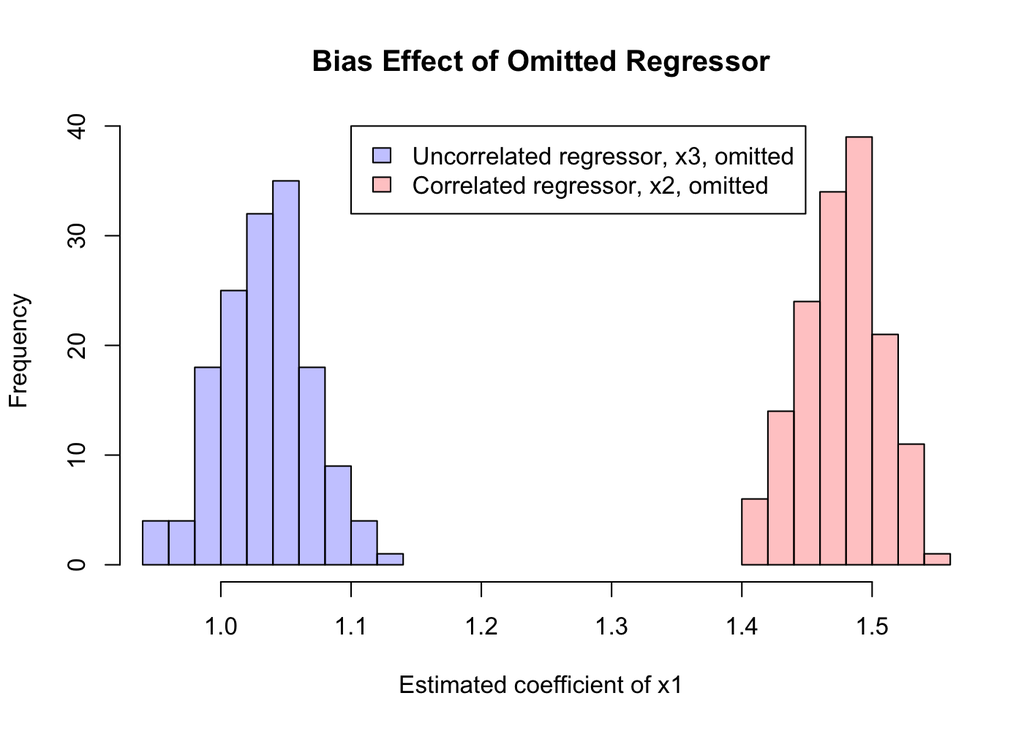

```r
x1hist(x1c)
```

Adding even irrelevant regressors can cause a model to tend toward a perfect fit.

In the figure, adding random regressors decreased deviance.

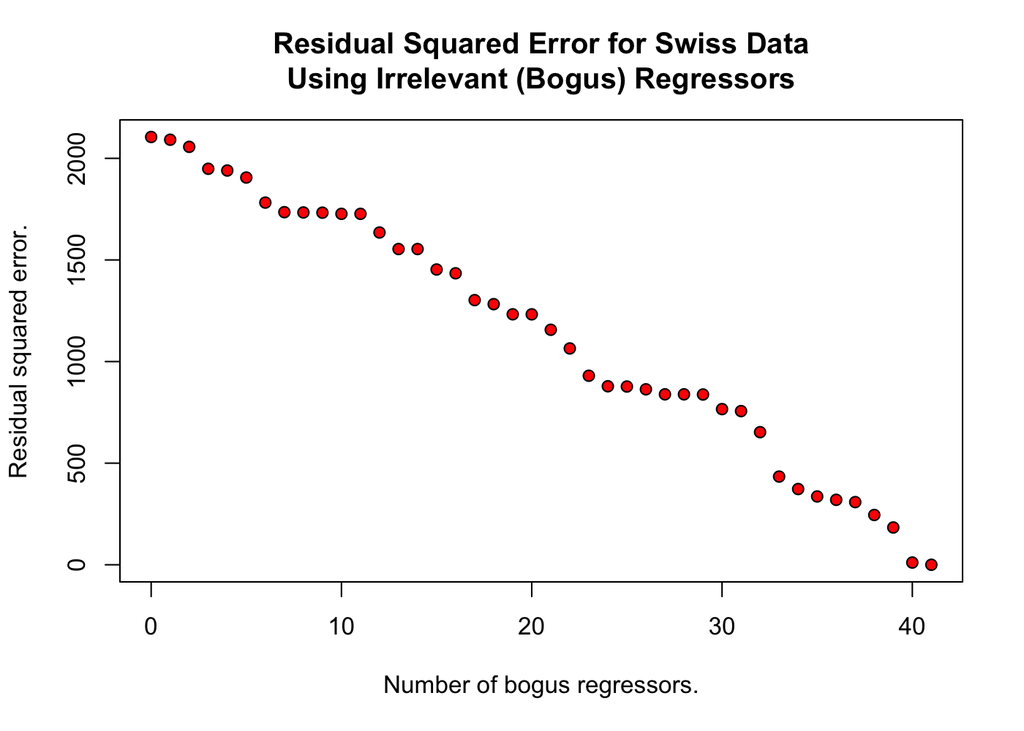

```r
bogus()
```

fit1: regress Fertility on Agriculture

fit3: regress Fertility on Agriculture and two additonal regressors, Examination and Education

```r
head(swiss)
```

```
             Fertility Agriculture Examination Education Catholic Infant.Mortality
Courtelary        80.2        17.0          15        12     9.96             22.2
Delemont          83.1        45.1           6         9    84.84             22.2
Franches-Mnt      92.5        39.7           5         5    93.40             20.2
Moutier           85.8        36.5          12         7    33.77             20.3
Neuveville        76.9        43.5          17        15     5.16             20.6
Porrentruy        76.1        35.3           9         7    90.57             26.6
```

```r
fit1 <- lm(Fertility ~ Agriculture, data = swiss)
fit3 <- lm(Fertility ~ Agriculture + Examination + Education , data = swiss)

# assess the significance of the two added regressors
# H_0: regressors are not significant
anova(fit1, fit3)
```

```
Analysis of Variance Table

Model 1: Fertility ~ Agriculture
Model 2: Fertility ~ Agriculture + Examination + Education
  Res.Df    RSS Df Sum of Sq      F    Pr(>F)
1     45 6283.1
2     43 3180.9  2    3102.2 20.968 4.407e-07 ***
---
Signif. codes:  0 '***' 0.001 '**' 0.01 '*' 0.05 '.' 0.1 ' ' 1
```

The three asterisks, ***, at the lower right of the printed table indicate that the null hypothesis is rejected at the 0.001 level, so at least one of the two additional regressors is significant.

```r
# calculate the residual sum of squares (dviance)
deviance(fit3) # same as RSS
```

```
[1] 3180.925
```

```r
# Calculate F value:
d<- deviance(fit3)/43# number of samples(47) - number of predictors(4)
n <- (deviance(fit1) - deviance(fit3))/2
f_anova <- n/d
f_anova
```

```
[1] 20.96783
```

```r
# p-value
# which is the probability that a value of n/d or larger would be drawn from an F distribution
pf(n/d, 2, 43, lower.tail=FALSE)
```

```
[1] 4.406913e-07
```

Based on the p-value, a false rjection of H_0 is unlikely. `fit3` seems to be better than `fit1`, however, analysis of variance is sensitive to its assumption that model residuals are approximately normal. If they are not, p-value could be small for that reason. ** Test residuals for normality**.

```r
shapiro.test(fit3$residuals)
```

```
    Shapiro-Wilk normality test

data:  fit3$residuals
W = 0.97276, p-value = 0.336
```

The Shapiro-Wilk p-value of 0.336 fails to reject normality, supporting confidence in the analysis of variance

```r
fit5 <- lm(Fertility ~ Agriculture + Examination + Education + Catholic, swiss)
fit6 <- lm(Fertility ~ ., swiss)

# assess the significance of the two added regressors
# H_0: regressors are not significant
anova(fit1, fit3, fit5, fit6)
```

```
Analysis of Variance Table

Model 1: Fertility ~ Agriculture
Model 2: Fertility ~ Agriculture + Examination + Education
Model 3: Fertility ~ Agriculture + Examination + Education + Catholic
Model 4: Fertility ~ Agriculture + Examination + Education + Catholic +
    Infant.Mortality
  Res.Df    RSS Df Sum of Sq       F    Pr(>F)
1     45 6283.1
2     43 3180.9  2   3102.19 30.2107 8.638e-09 ***
3     42 2513.8  1    667.13 12.9937 0.0008387 ***
4     41 2105.0  1    408.75  7.9612 0.0073357 **
---
Signif. codes:  0 '***' 0.001 '**' 0.01 '*' 0.05 '.' 0.1 ' ' 1
```

Each model is a significant improvement on its predecessor